#### ID: 201554403

#### Word Count: 2188

# Investigating urban environment pollutant concentrations of Carbon Monoxide (CO), Non Metanic Hydrocarbons (NMHC), Benzene (C6H6) and Total Nitrogen Oxides (NOx) and the effect of temperature and humidity on NOx

## Exploratory Data Analysis & Interpretation

```python
#importing relevant libraries
import pandas as pd
import seaborn as sns
import matplotlib.pyplot as plt
import numpy as np
```

```python
#reading in the data file
df = pd.read_csv("/Users/sarahahmed/Library/CloudStorage/OneDrive-TheUniversityofLiverpool/GDS MASTERS/ENVS615 Data Management and Wrangling/assignment 1/air+quality/AirQualityUCI.csv", delimiter=";")
```

```python
#looking at first 5 rows of data
df.head(5)
```

|  | Date | Time | CO(GT) | PT08.S1(CO) | NMHC(GT) | C6H6(GT) | PT08.S2(NMHC) | NOx(GT) | PT08.S3(NOx) | NO2(GT) | PT08.S4(NO2) | PT08.S5(O3) | T | RH | AH | Unnamed: 15 | Unnamed: 16 |
| --- | --- | --- | --- | --- | --- | --- | --- | --- | --- | --- | --- | --- | --- | --- | --- | --- | --- |
| 0 | 10/03/2004 | 18.00.00 | 2,6 | 1360.0 | 150.0 | 11,9 | 1046.0 | 166.0 | 1056.0 | 113.0 | 1692.0 | 1268.0 | 13,6 | 48,9 | 0,7578 | NaN | NaN |
| 1 | 10/03/2004 | 19.00.00 | 2 | 1292.0 | 112.0 | 9,4 | 955.0 | 103.0 | 1174.0 | 92.0 | 1559.0 | 972.0 | 13,3 | 47,7 | 0,7255 | NaN | NaN |
| 2 | 10/03/2004 | 20.00.00 | 2,2 | 1402.0 | 88.0 | 9,0 | 939.0 | 131.0 | 1140.0 | 114.0 | 1555.0 | 1074.0 | 11,9 | 54,0 | 0,7502 | NaN | NaN |
| 3 | 10/03/2004 | 21.00.00 | 2,2 | 1376.0 | 80.0 | 9,2 | 948.0 | 172.0 | 1092.0 | 122.0 | 1584.0 | 1203.0 | 11,0 | 60,0 | 0,7867 | NaN | NaN |
| 4 | 10/03/2004 | 22.00.00 | 1,6 | 1272.0 | 51.0 | 6,5 | 836.0 | 131.0 | 1205.0 | 116.0 | 1490.0 | 1110.0 | 11,2 | 59,6 | 0,7888 | NaN | NaN |

```python
#looking at last 5 rows of data
df.tail(5)
```

|  | Date | Time | CO(GT) | PT08.S1(CO) | NMHC(GT) | C6H6(GT) | PT08.S2(NMHC) | NOx(GT) | PT08.S3(NOx) | NO2(GT) | PT08.S4(NO2) | PT08.S5(O3) | T | RH | AH | Unnamed: 15 | Unnamed: 16 |
| --- | --- | --- | --- | --- | --- | --- | --- | --- | --- | --- | --- | --- | --- | --- | --- | --- | --- |
| 9466 | NaN | NaN | NaN | NaN | NaN | NaN | NaN | NaN | NaN | NaN | NaN | NaN | NaN | NaN | NaN | NaN | NaN |
| 9467 | NaN | NaN | NaN | NaN | NaN | NaN | NaN | NaN | NaN | NaN | NaN | NaN | NaN | NaN | NaN | NaN | NaN |
| 9468 | NaN | NaN | NaN | NaN | NaN | NaN | NaN | NaN | NaN | NaN | NaN | NaN | NaN | NaN | NaN | NaN | NaN |
| 9469 | NaN | NaN | NaN | NaN | NaN | NaN | NaN | NaN | NaN | NaN | NaN | NaN | NaN | NaN | NaN | NaN | NaN |
| 9470 | NaN | NaN | NaN | NaN | NaN | NaN | NaN | NaN | NaN | NaN | NaN | NaN | NaN | NaN | NaN | NaN | NaN |

### Data cleaning and transformation

#### First creating a new dataframe to remove irrelevant concentration columns as I've chosen to focus only on the ground Truth hourly averaged concentrations taken (CO, NMHC, C6H6 and NOx)as they are of focus in this research

```python
# create new dataframe with desired columns for:
# Date, Time, CO, Non Metanic Hydrocarbons, Benzene, Total Nitrogen Oxides, Temperature and Relative Humidity
columns_to_include = ['Date', 'Time', 'CO(GT)', 'NMHC(GT)', 'C6H6(GT)', 'NOx(GT)',  'T', 'RH'  ]
pollutant_conc_df = df[columns_to_include].copy()
pollutant_conc_df.tail(10)
```

|  | Date | Time | CO(GT) | NMHC(GT) | C6H6(GT) | NOx(GT) | T | RH |
| --- | --- | --- | --- | --- | --- | --- | --- | --- |
| 9461 | NaN | NaN | NaN | NaN | NaN | NaN | NaN | NaN |
| 9462 | NaN | NaN | NaN | NaN | NaN | NaN | NaN | NaN |
| 9463 | NaN | NaN | NaN | NaN | NaN | NaN | NaN | NaN |
| 9464 | NaN | NaN | NaN | NaN | NaN | NaN | NaN | NaN |
| 9465 | NaN | NaN | NaN | NaN | NaN | NaN | NaN | NaN |
| 9466 | NaN | NaN | NaN | NaN | NaN | NaN | NaN | NaN |
| 9467 | NaN | NaN | NaN | NaN | NaN | NaN | NaN | NaN |
| 9468 | NaN | NaN | NaN | NaN | NaN | NaN | NaN | NaN |
| 9469 | NaN | NaN | NaN | NaN | NaN | NaN | NaN | NaN |
| 9470 | NaN | NaN | NaN | NaN | NaN | NaN | NaN | NaN |

```python
#removing rows only where all values are NaN
pollutant_conc_df = pollutant_conc_df.dropna(how='all')
pollutant_conc_df.tail(10)
```

|  | Date | Time | CO(GT) | NMHC(GT) | C6H6(GT) | NOx(GT) | T | RH |
| --- | --- | --- | --- | --- | --- | --- | --- | --- |
| 9347 | 04/04/2005 | 05.00.00 | 0,5 | -200.0 | 1,3 | 77.0 | 10,4 | 59,9 |
| 9348 | 04/04/2005 | 06.00.00 | 1,1 | -200.0 | 4,4 | 182.0 | 9,5 | 63,1 |
| 9349 | 04/04/2005 | 07.00.00 | 4,0 | -200.0 | 17,4 | 594.0 | 9,7 | 61,9 |
| 9350 | 04/04/2005 | 08.00.00 | 5,0 | -200.0 | 22,4 | 586.0 | 13,5 | 48,9 |
| 9351 | 04/04/2005 | 09.00.00 | 3,9 | -200.0 | 13,6 | 523.0 | 18,2 | 36,3 |
| 9352 | 04/04/2005 | 10.00.00 | 3,1 | -200.0 | 13,5 | 472.0 | 21,9 | 29,3 |
| 9353 | 04/04/2005 | 11.00.00 | 2,4 | -200.0 | 11,4 | 353.0 | 24,3 | 23,7 |
| 9354 | 04/04/2005 | 12.00.00 | 2,4 | -200.0 | 12,4 | 293.0 | 26,9 | 18,3 |
| 9355 | 04/04/2005 | 13.00.00 | 2,1 | -200.0 | 9,5 | 235.0 | 28,3 | 13,5 |
| 9356 | 04/04/2005 | 14.00.00 | 2,2 | -200.0 | 11,9 | 265.0 | 28,5 | 13,1 |

#### I decided to turn missing values (-200) into NaN values as using the mean takes outliers into account which would display my data incorrectly and this way I can ignore them in my visualisations

```python
#Turning -200 (missing values) into NaN
pollutant_conc_df['CO(GT)'] = pollutant_conc_df['CO(GT)'].replace(-200, np.nan)
pollutant_conc_df['NMHC(GT)'] = pollutant_conc_df['NMHC(GT)'].replace(-200, np.nan)
pollutant_conc_df['C6HC(GT)'] = pollutant_conc_df['C6H6(GT)'].replace(-200, np.nan)
pollutant_conc_df['NOx(GT)'] = pollutant_conc_df['NOx(GT)'].replace(-200, np.nan)
pollutant_conc_df['T'] = pollutant_conc_df['T'].replace(-200, np.nan)
pollutant_conc_df['RH'] = pollutant_conc_df['RH'].replace(-200, np.nan)
```

```python
pollutant_conc_df['CO(GT)'] = pollutant_conc['CO(GT)'].str.replace(',', '.')
pollutant_conc_df['C6H6(GT)'] = pollutant_conc['C6H6(GT)'].str.replace(',', '.')
pollutant_conc_df['T'] = pollutant_conc['T'].str.replace(',', '.')
pollutant_conc_df['RH'] = pollutant_conc['RH'].str.replace(',', '.')
```

```python
pollutant_conc_df.tail(10)
```

|  | Date | Time | CO(GT) | NMHC(GT) | C6H6(GT) | NOx(GT) | T | RH | C6HC(GT) |
| --- | --- | --- | --- | --- | --- | --- | --- | --- | --- |
| 9347 | 04/04/2005 | 05.00.00 | 0.5 | NaN | 1.3 | 77.0 | 10.4 | 59.9 | 1,3 |
| 9348 | 04/04/2005 | 06.00.00 | 1.1 | NaN | 4.4 | 182.0 | 9.5 | 63.1 | 4,4 |
| 9349 | 04/04/2005 | 07.00.00 | 4.0 | NaN | 17.4 | 594.0 | 9.7 | 61.9 | 17,4 |
| 9350 | 04/04/2005 | 08.00.00 | 5.0 | NaN | 22.4 | 586.0 | 13.5 | 48.9 | 22,4 |
| 9351 | 04/04/2005 | 09.00.00 | 3.9 | NaN | 13.6 | 523.0 | 18.2 | 36.3 | 13,6 |
| 9352 | 04/04/2005 | 10.00.00 | 3.1 | NaN | 13.5 | 472.0 | 21.9 | 29.3 | 13,5 |
| 9353 | 04/04/2005 | 11.00.00 | 2.4 | NaN | 11.4 | 353.0 | 24.3 | 23.7 | 11,4 |
| 9354 | 04/04/2005 | 12.00.00 | 2.4 | NaN | 12.4 | 293.0 | 26.9 | 18.3 | 12,4 |
| 9355 | 04/04/2005 | 13.00.00 | 2.1 | NaN | 9.5 | 235.0 | 28.3 | 13.5 | 9,5 |
| 9356 | 04/04/2005 | 14.00.00 | 2.2 | NaN | 11.9 | 265.0 | 28.5 | 13.1 | 11,9 |

```python
#checking my data is all numeric to plot
print(pollutant_conc_df.dtypes)
```

```
Date         object
Time         object
CO(GT)       object
NMHC(GT)    float64
C6H6(GT)     object
NOx(GT)     float64
T            object
RH           object
C6HC(GT)     object
dtype: object
```

```python
#fixing data to be numeric
pollutant_conc_df['CO(GT)'] = pd.to_numeric(pollutant_conc_df['CO(GT)'])
pollutant_conc_df['NMHC(GT)'] = pd.to_numeric(pollutant_conc_df['NMHC(GT)'])
pollutant_conc_df['C6H6(GT)'] = pd.to_numeric(pollutant_conc_df['C6H6(GT)'])
pollutant_conc_df['NOx(GT)'] = pd.to_numeric(pollutant_conc_df['NOx(GT)'])
pollutant_conc_df['T'] = pd.to_numeric(pollutant_conc_df['T'])
pollutant_conc_df['RH'] = pd.to_numeric(pollutant_conc_df['RH'])
```

```python
#checking changing data types worked
print(pollutant_conc_df.dtypes)
```

```
Date         object
Time         object
CO(GT)      float64
NMHC(GT)    float64
C6H6(GT)    float64
NOx(GT)     float64
T           float64
RH          float64
C6HC(GT)     object
dtype: object
```

### Visualisations

#### Figure 1: Line graph plotting pollutant concentrations from 2004-2005

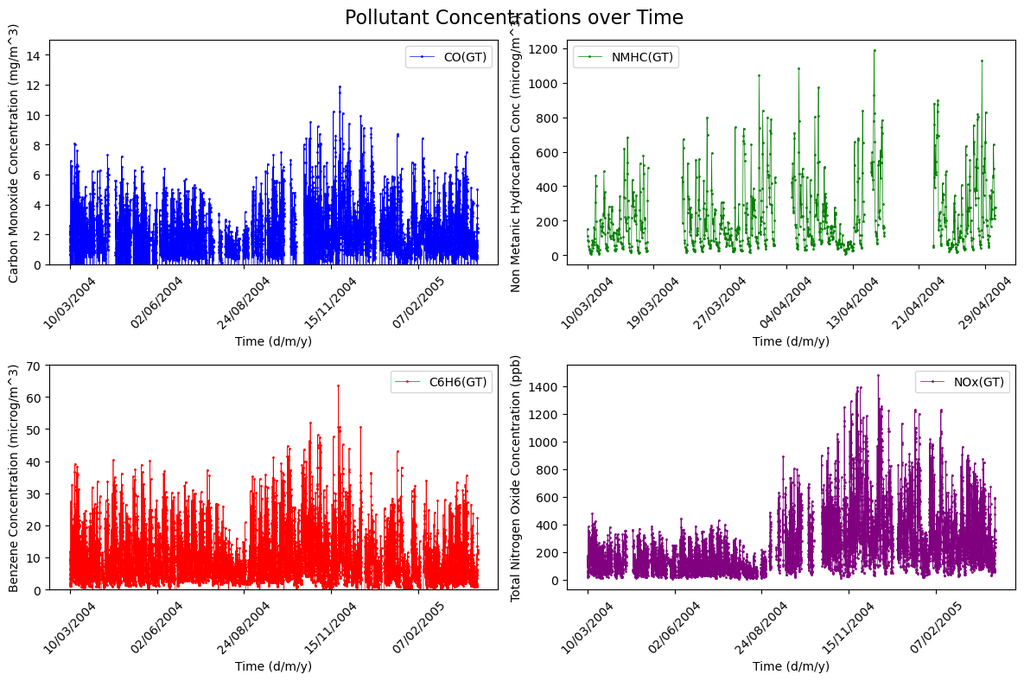

```python
#making 4 subplots for comparison

pollutant = ['CO(GT)', 'NMHC(GT)', 'C6H6(GT)', 'NOx(GT)']
color = ['blue', 'green', 'red', 'purple']

# Create a figure with 4 subplots (2 rows, 2 columns)
fig, axs = plt.subplots(2, 2, figsize=(12, 8))

# Loop through pollutants and subplots
for ax, pollutant, color in zip(axs.flat, pollutants, color):
    # Create a line plot for each pollutant
    pollutant_conc_df.plot(x='Date', y=pollutant, ax=ax, color=color, marker='o', linestyle='-', linewidth=0.5, markersize=1)

 # Set labels and title for each subplot
ax.set_xlabel('Time')
ax.set_ylabel('Concentration')


#setting specific axis ranges
axs[0, 0].set_ylim(0, 15)
axs[1, 0].set_ylim(0, 70)

axs[0, 1].tick_params(axis='x', rotation=45)
axs[1, 1].tick_params(axis='x', rotation=45)
axs[1, 0].tick_params(axis='x', rotation=45)
axs[0, 0].tick_params(axis='x', rotation=45)

#setting specific axis labels
axs[0, 0].set_xlabel('Time (d/m/y)')
axs[0, 0].set_ylabel('Carbon Monoxide Concentration (mg/m^3)')

axs[1, 0].set_xlabel('Time (d/m/y)')
axs[1, 0].set_ylabel('Benzene Concentration (microg/m^3)')

axs[0, 1].set_xlabel('Time (d/m/y)')
axs[0, 1].set_ylabel('Non Metanic Hydrocarbon Conc (microg/m^3)')

axs[1, 1].set_xlabel('Time (d/m/y)')
axs[1, 1].set_ylabel('Total Nitrogen Oxide Concentration (ppb)')

fig.suptitle('Pollutant Concentrations over Time', fontsize=16)

# Adjust layout to prevent overlapping
plt.tight_layout()

# Display the plot
plt.show()
```

##### Figure 1 shows the fluctuations present in each pollutant over the timeframe the data was collected (2004 values for NMHC due to missing values). The most significant increase in concentration would be Total Nitrogen Oxides with a higher concentration being seen at the end of 2004/start of 2005 than the start of 2004. This could be associsated with temperature/humudity rising and further investigated in figures 2 and 3. The flucutations can be accreidted to a variet of factors such as weekday vs weekends altering traffic patterns or seasonal influences, there is clearly not a stable concentration throughout the year. As the y axis scales vary it's hard to compare the between the pollutants however it offers a relative insight into how they indivudally vary.

#### Figure 2: Scatter plot showing the relationship between NOx and Temperature

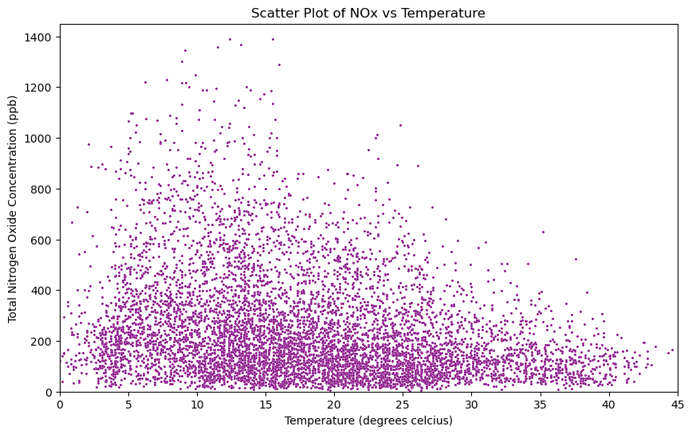

```python
# Ensure the temperature column ('T') is numeric
df['T'] = pd.to_numeric(df['T'], errors='coerce')

# Sort by Temperature ('T') to ensure an increasing order on the x-axis
df = df.sort_values(by='T')

# Filter the DataFrame to include only 'T' values between 0 and 30
df_filtered = df[(df['T'] >= 0) & (df['T'] <= 30)]

# Create a scatter plot
plt.figure(figsize=(10, 6))  # Set the figure size
sns.scatterplot(x='T', y='NOx(GT)', data=pollutant_conc_df, s=5, color= 'purple',  alpha=1)

# Set x-axis and y-axis limits
plt.xlim(0, 45)
plt.ylim(0, 1450)

# Add titles and labels
plt.title("Scatter Plot of NOx vs Temperature")
plt.xlabel("Temperature (degrees celcius)")
plt.ylabel("Total Nitrogen Oxide Concentration (ppb)")

# Show the plot
plt.show()
```

##### Figure 2 delves into Total Nitrogen Oxide concentrations as in figure 1 we saw it had a interesting increase thorughout the year however, looking at figure 2 there isn't a increase in NOx as temperature increases which could've been expected from past literature. There seems to be a certain temperature range where the pollutant concentration peaks around 5-15 degrees celcius, this could be due to it being a optimum temperature where certain chemical reactions occur. Or there may just me a cluster of data as this was the average temperature for Italy in the year. Many points are clustering at the bottom of the graph showing a very low NOx as the temperature varies, showing that it potneitally isn't one of the most released pollutants hence not to be as much of a concern however, this can't be assume without conducting further research in the area.

#### Figure 3: Scatter plot showing the relationship between NOx and Relative Humidity

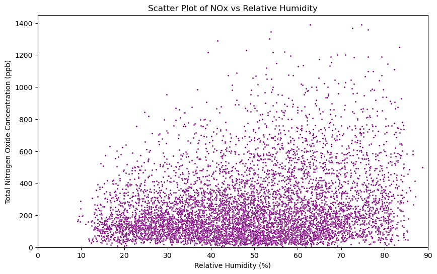

```python
# Ensure the relative humidity column ('RH') is numeric
df['RH'] = pd.to_numeric(df['RH'], errors='coerce')

# Sort by Relative Humidity ('RH') to ensure an increasing order on the x-axis
df = df.sort_values(by='RH')

# Filter the DataFrame to include only 'RH' values between 0 and 100 (assuming RH is in percentage)
df_filtered = df[(df['RH'] >= 0) & (df['RH'] <= 100)]

# Create a scatter plot
plt.figure(figsize=(10, 6))  # Set the figure size
sns.scatterplot(x='RH', y='NOx(GT)', data=pollutant_conc_df, s=5, color='purple', alpha=1)

# Set x-axis and y-axis limits
plt.xlim(0, 90)
plt.ylim(0, 1450)

# Add titles and labels
plt.title("Scatter Plot of NOx vs Relative Humidity")
plt.xlabel("Relative Humidity (%)")
plt.ylabel("Total Nitrogen Oxide Concentration (ppb)")

# Show the plot
plt.show()
```

##### Figure 3 looks at the influence of relative humidity on Total Nitrogen Oxide concentrations and shows that as the Humidity increases genereally so does NOx, displaying a completely different trend to figure 2. It can be interepreted that NOx thrives in a humid condition, which can be associated back to Jayamurugan et al (2013) stating humidity traps pollutants and speeds up chemical reactions. Again there is clustering at low NOx values along the x axis showing fewer extreme values, although these are to not be ignored.

### Summary Statistics for NOx

```python
#mean, median, mode, range
mean_value = df['NOx'].mean()
median_value = df['NOx'].median()
mode_value = df['NOx'].mode()[0]
range_value = df['NOx'].max() - df['NOx'].min()

data = {    'Measure': ['Mean', 'Median', 'Mode', 'Range'],
    'NOx': [246.8967349054159, 180.0, 89.0, 1477.0],

}

# Create a DataFrame
df = pd.DataFrame(data)

# Display the DataFrame
df
```

|  | Measure | NOx |
| --- | --- | --- |
| 0 | Mean | 246.896735 |
| 1 | Median | 180.000000 |
| 2 | Mode | 89.000000 |
| 3 | Range | 1477.000000 |

## References

1. Bray, C.D., Battye, W.H., Aneja, V.P. and Schlesinger, W.H., 2021. Global emissions of NH3, NOx, and N2O from biomass burning and the impact of climate change. Journal of the Air & Waste Management Association, 71(1), pp.102-114.

Chen, X., Zhu, T., Wang, Q., Wang, T., Chen, W., Yao, Y., Xu, Y. and Qiu, X., 2024. 2. Higher temperature and humidity exacerbate pollutant-associated lung dysfunction in the elderly. Environmental Research, 245, p.118039. 3. D'Amato, G., Cecchi, L., D'amato, M., & Liccardi, G. (2010). Urban air pollution and climate change as environmental risk factors of respiratory allergy: an update. Journal of Investigational Allergology and Clinical Immunology, 20(2), pp. 95-102. 4. De Vito, S., Massera, E., Piga, M., Martinotto, L., & Di Francia, G. (2008). On-field calibration of an electronic nose for benzene estimation in an urban pollution monitoring scenario. Sensors and Actuators B: Chemical, 129(2), pp. 750-757. 5. Jayamurugan, R., Kumaravel, B., Palanivelraja, S., & Chockalingam, M.P. (2013). Influence of temperature, relative humidity, and seasonal variability on ambient air quality in a coastal urban area. International Journal of Atmospheric Sciences, 2013(1), p. 264046. 6. Kaushik, N., & Das, R.M. (2023). Investigation of NOx and related secondary pollutants at Anand Vihar, one of the most polluted areas of Delhi. Urban Climate, 52, p. 101747. 7. Liang, L., Wang, Z., & Li, J. (2019). The effect of urbanization on environmental pollution in rapidly developing urban agglomerations. Journal of Cleaner Production, 237, p. 117649. 8. Rocha, M., Krapp, M., Guetschow, J., Jeffery, L., Hare, B. and Schaeffer, M., 2015. Historical Responsibility for Climate Change–from countries emissions to contribution to temperature increase. Climate Analytics and Potsdam Institute for Climate Impact Research: Potsdam, Germany. 9. San José, R., Pérez, J.L., Pérez, L., & Barras, R.M.G. (2018). Effects of climate change on the health of citizens: Modeling urban weather and air pollution. Energy, 165, pp. 53-62. 10. Stone Jr, B. (2005). Urban heat and air pollution: An emerging role for planners in the climate change debate. Journal of the American Planning Association, 71(1), pp. 13-25.